# First Steps

Remember that aesthetic mappings in ggplot are at a global level so they are passed down to each of geom layers. In this example this will make every geom map to color = “species”

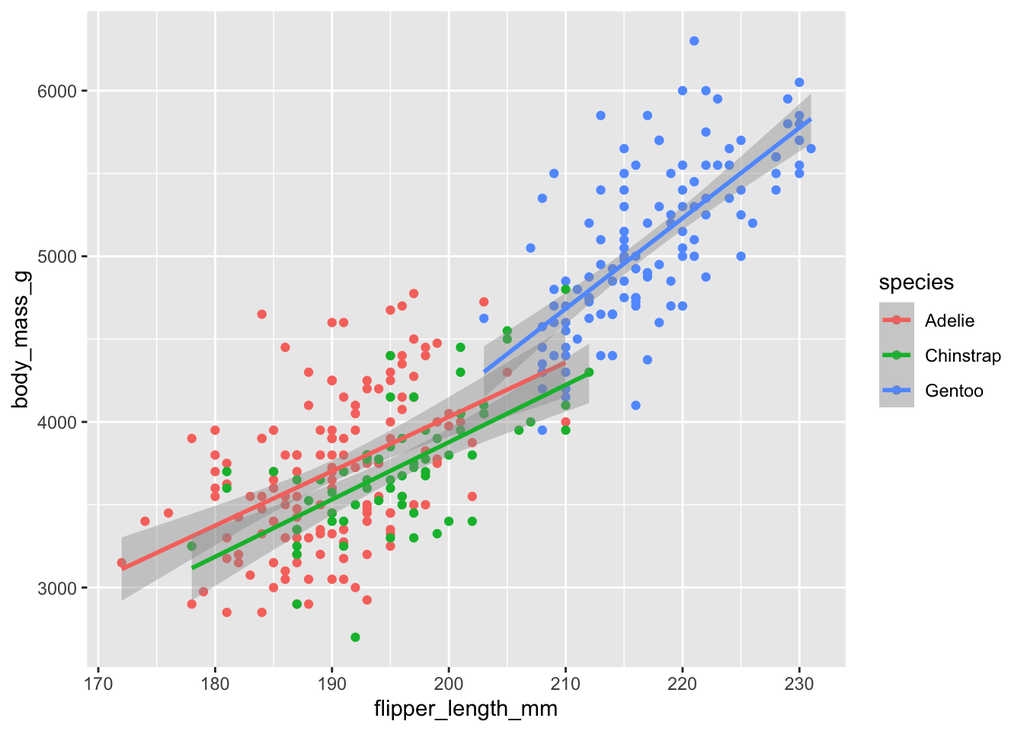

```r
ggplot(
  data = penguins,
  mapping = aes(x = flipper_length_mm,
                y = body_mass_g,
                color = species)
) +
  geom_point() +
  geom_smooth(method = "lm")
```

Thus we should declare the color mapping in the local level

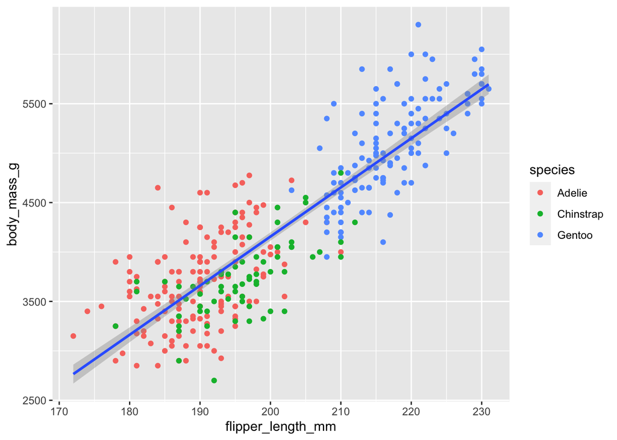

```r
ggplot(
  data = penguins,
  mapping = aes(x = flipper_length_mm,
                y = body_mass_g)
) +
  geom_point(mapping = aes(color = species)) +
  geom_smooth(method = "lm")
```

We should always use shapes to differentiate b/c of color blindness

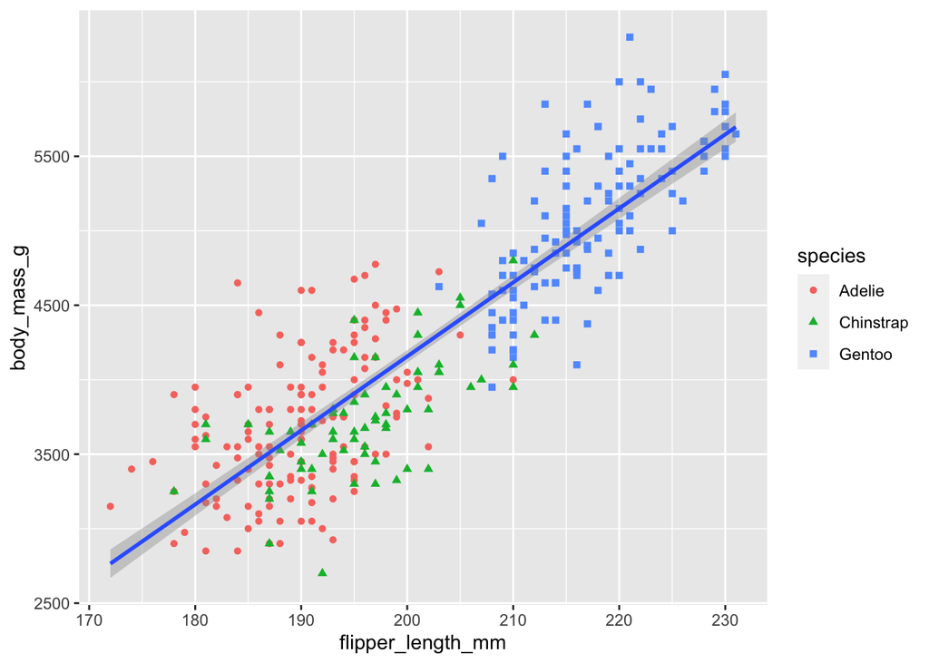

```r
ggplot(
  data = penguins,
  mapping = aes(x = flipper_length_mm,
                y = body_mass_g)
) +
  geom_point(mapping = aes(color = species, shape = species)) +
  geom_smooth(method = "lm")
```

Then add labels with labs() and colorblind support with scale_color_colorblind()

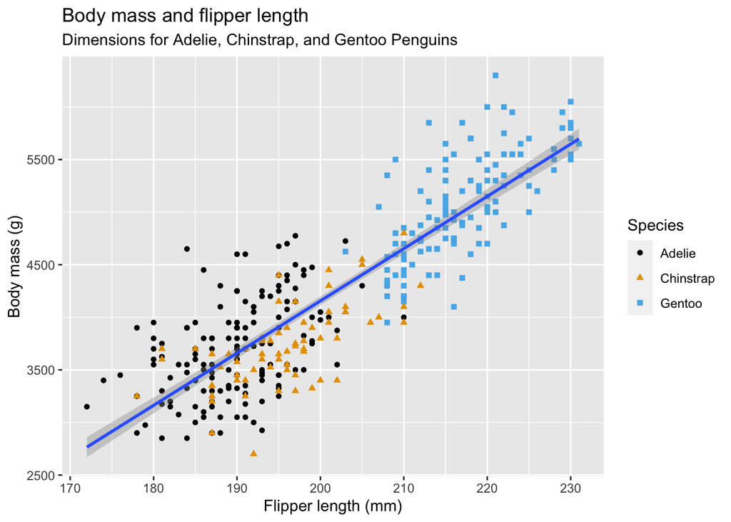

```r
ggplot(
  data = penguins,
  mapping = aes(x = flipper_length_mm,
                y = body_mass_g)
) +
  geom_point(mapping = aes(color = species, shape = species)) +
  geom_smooth(method = "lm") +
  labs(
    title = "Body mass and flipper length",
    subtitle = "Dimensions for Adelie, Chinstrap, and Gentoo Penguins",
    x = "Flipper length (mm)", y = "Body mass (g)",
    color = "Species", shape = "Species"
  ) +
  scale_color_colorblind()
```

## Exercises

1. How many rows are in penguins? How many columns?

   ```r
   glimpse(penguins)
   ```

   ```
   ## Rows: 344
   ## Columns: 8
   ## $ species           <fct> Adelie, Adelie, Adelie, Adelie, Adelie, Adelie, Adel…
   ## $ island            <fct> Torgersen, Torgersen, Torgersen, Torgersen, Torgerse…
   ## $ bill_length_mm    <dbl> 39.1, 39.5, 40.3, NA, 36.7, 39.3, 38.9, 39.2, 34.1, …
   ## $ bill_depth_mm     <dbl> 18.7, 17.4, 18.0, NA, 19.3, 20.6, 17.8, 19.6, 18.1, …
   ## $ flipper_length_mm <int> 181, 186, 195, NA, 193, 190, 181, 195, 193, 190, 186…
   ## $ body_mass_g       <int> 3750, 3800, 3250, NA, 3450, 3650, 3625, 4675, 3475, …
   ## $ sex               <fct> male, female, female, NA, female, male, female, male…
   ## $ year              <int> 2007, 2007, 2007, 2007, 2007, 2007, 2007, 2007, 2007…
   ```

2. What does the bill_depth_mm variable in the penguins data frame describe? Read the help for ?penguins to find out.

[output not shown]

3. Make a scatterplot of bill_depth_mm versus bill_length_mm. That is, make a scatterplot with bill_depth_mm on the y-axis and bill_length_mm on the x-axis. Describe the relationship between these two variables.

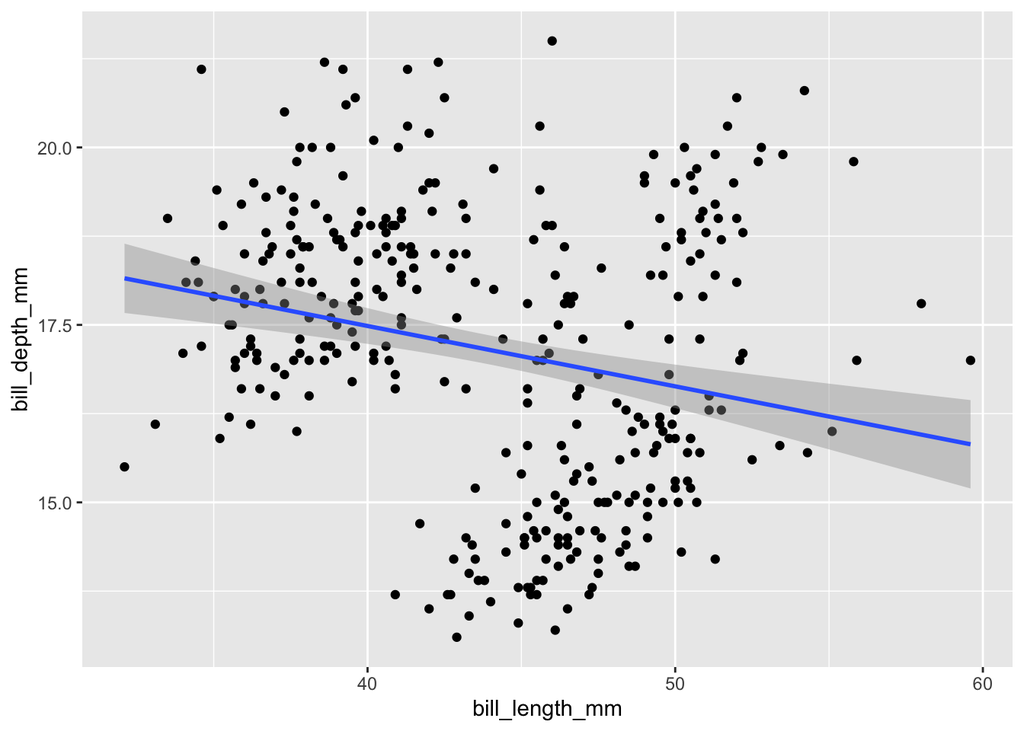

   ```r
   ggplot(
     data = penguins,
     mapping = aes(x = bill_length_mm,y = bill_depth_mm)
   ) +
     geom_point() +
     geom_smooth(method = "lm")
   ```